# Filter Joins (like vlookup)

Jeff Manson

12/8/2019

read in 3 files - invert_counts_curated.xlsx - fish_counts_currated.csv - Kelp_countes_curated.xlsx

```r
inverted_counts <- read_excel(here("R-workshop-data","invert_counts_curated.xlsx"))

fish_counts <- read_csv(here("R-workshop-data","fish_counts_curated.csv"))
kelp_count_abur <- read_excel(here("R-workshop-data","kelp_counts_curated.xlsX"))
```

Select is for columns filter is for rows

## Filter to match rows based on charater string

only keep observations from fishcounts where common_name = “garibaldi”

```r
fish_garibaldi <- fish_counts %>%
  filter(common_name == "garibaldi")
```

## filter to keep or exclude based on numerics

```r
fish_over50 <- fish_counts %>%
  filter(total_count >=50)
```

Create a subset for fish at “mohk”

```r
fish_mohk <- fish_counts %>%
  filter(site == "mohk")
```

Filter to keep rows that match this or that Keep observation for garibaldi, blacksmith, or balck surfperch

use the in %in% operatior to look for any matches within a vector

```r
fish_3sp <- fish_counts %>%
  filter(common_name %in% c("garibaldi","blacksmith","black surfperch"))
```

Using OR statments

```r
fish_3sp_v2 <- fish_counts %>%
  filter(common_name == "garibaldi" | common_name == "blacksmith"| common_name== "black surfperch")
```

## Filter to return rows that match multiple varibable

I want a subset called urchin_abur_mohk that - site is abur oe mohk AND -specied is “purple urchin”

Some ways to this - seperate “AND” conditionws withing a single filter line by a comma, - seperate “and” conditions withing a signle filer by & - multiple filter statements with %>%

```r
urchin_abur_mohk <- inverted_counts %>%
  filter(site == "abur" | site == "mohk",common_name == "purple urchin")
```

Create a subset from fish couents called low_gb_rw that only contains; - obseravtations for "garibaldi and rock wrasse where totatl total count < 10

```r
low_gb_rw <- fish_counts %>%
  filter(common_name %in% c("garibaldi", "rock wrasse"), total_count <10)
```

## Filter rows that do not match conditions

Use != (indicaties does not match)

make a subset from fish counts that doesn not contain mohawk reef

```r
fish_no_mohk <- fish_counts %>%
  filter(site != "mohk")
```

An example of filter as part of piped sequence:

```r
senorita_allyears <- fish_counts %>%
  filter(common_name == "senorita") %>%
  group_by(site) %>%
  summarize(count_all_years = sum(total_count))
```

## A Couple ways of joining data frames

- full_join() keeps everything (safe join)
- left_join() If mergeing A and B will only retain observationsin fromB that have matches in A

```r
fish_2016_2017 <- fish_counts %>%
  filter(year == 2016 | year == 2017)
```

## coerc

```r
kelp_count_abur <- kelp_count_abur %>%
  mutate(year = as.numeric(year))
```

join Df with kelp counts abur

```r
abur_kelp_join <- fish_2016_2017 %>%
  full_join(kelp_count_abur, by = c("year","site"))
```

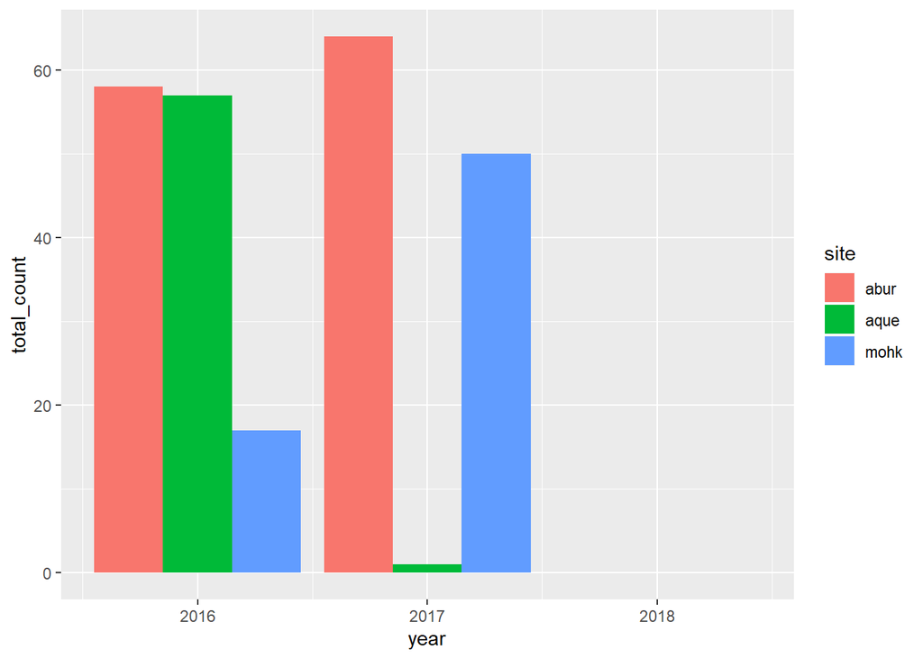

```r
ggplot(abur_kelp_join, aes(x=year, y= total_count))+
  geom_col(aes(fill= site), position = "dodge")
```